# HeartDisease Prediction

### Step 1 | Import Libraries

```python
import numpy as np
import pandas as pd
import seaborn as sns
import matplotlib.pyplot as plt
import os

import matplotlib.pyplot as plt
import seaborn as sns

from sklearn.preprocessing import OrdinalEncoder
from sklearn.preprocessing import MinMaxScaler

from sklearn.model_selection import train_test_split,GridSearchCV,ParameterGrid

from imblearn.over_sampling import ADASYN

from collections import Counter

from sklearn.ensemble import RandomForestClassifier
from sklearn.tree import DecisionTreeClassifier

from sklearn.neighbors import KNeighborsClassifier

from sklearn.svm import SVC

from sklearn.linear_model import LogisticRegression

from sklearn.naive_bayes import GaussianNB

from xgboost import XGBClassifier

from sklearn.ensemble import GradientBoostingClassifier

from tensorflow import keras
from tensorflow.keras import layers

from sklearn.metrics import accuracy_score, classification_report, confusion_matrix
```

### Step 2 | Read Dataset

```python
df = pd.read_csv('/kaggle/input/heartdisease/HeartDisease.csv')
```

```python
df.head()
```

|  | HeartDiseaseorAttack | HighBP | HighChol | BMI | Smoker | Diabetes | PhysActivity | Fruits | Veggies | HvyAlcoholConsump | MentHlth | PhysHlth | Sex | Age | Education | Income |
| --- | --- | --- | --- | --- | --- | --- | --- | --- | --- | --- | --- | --- | --- | --- | --- | --- |
| 0 | 0.0 | 1.0 | 1.0 | 40.0 | 1.0 | 0.0 | 0.0 | 0.0 | 1.0 | 0.0 | 18.0 | 15.0 | 0.0 | 9.0 | 4.0 | 3.0 |
| 1 | 0.0 | 0.0 | 0.0 | 25.0 | 1.0 | 0.0 | 1.0 | 0.0 | 0.0 | 0.0 | 0.0 | 0.0 | 0.0 | 7.0 | 6.0 | 1.0 |
| 2 | 0.0 | 1.0 | 1.0 | 28.0 | 0.0 | 0.0 | 0.0 | 1.0 | 0.0 | 0.0 | 30.0 | 30.0 | 0.0 | 9.0 | 4.0 | 8.0 |
| 3 | 0.0 | 1.0 | 0.0 | 27.0 | 0.0 | 0.0 | 1.0 | 1.0 | 1.0 | 0.0 | 0.0 | 0.0 | 0.0 | 11.0 | 3.0 | 6.0 |
| 4 | 0.0 | 1.0 | 1.0 | 24.0 | 0.0 | 0.0 | 1.0 | 1.0 | 1.0 | 0.0 | 3.0 | 0.0 | 0.0 | 11.0 | 5.0 | 4.0 |

```python
df.shape
```

```
(253680, 16)
```

### Step 3 | Dataset Overview

```python
df.info()
```

```
<class 'pandas.core.frame.DataFrame'>
RangeIndex: 253680 entries, 0 to 253679
Data columns (total 16 columns):
 #   Column                Non-Null Count   Dtype
---  ------                --------------   -----
 0   HeartDiseaseorAttack  253680 non-null  float64
 1   HighBP                253680 non-null  float64
 2   HighChol              253680 non-null  float64
 3   BMI                   253680 non-null  float64
 4   Smoker                253680 non-null  float64
 5   Diabetes              253680 non-null  float64
 6   PhysActivity          253680 non-null  float64
 7   Fruits                253680 non-null  float64
 8   Veggies               253680 non-null  float64
 9   HvyAlcoholConsump     253680 non-null  float64
 10  MentHlth              253680 non-null  float64
 11  PhysHlth              253680 non-null  float64
 12  Sex                   253680 non-null  float64
 13  Age                   253680 non-null  float64
 14  Education             253680 non-null  float64
 15  Income                253680 non-null  float64
dtypes: float64(16)
memory usage: 31.0 MB
```

### Step 3.1 | Dataset Basic Information

```python
(df.isnull().mean()*100).sort_values(ascending = False)
```

```
HeartDiseaseorAttack    0.0
HighBP                  0.0
HighChol                0.0
BMI                     0.0
Smoker                  0.0
Diabetes                0.0
PhysActivity            0.0
Fruits                  0.0
Veggies                 0.0
HvyAlcoholConsump       0.0
MentHlth                0.0
PhysHlth                0.0
Sex                     0.0
Age                     0.0
Education               0.0
Income                  0.0
dtype: float64
```

**Inferences:**

*Number of Entries:* The dataset consists of 253680 entries, ranging from index 0 to 253679.

*Columns:* There are 16 columns in the dataset corresponding to various attributes of the patients and results of tests.

*Data Types:* Most of the columns are of the float64 data type.

*Missing Values:* There don't appear to be any missing values in the dataset as each column has 253680 non-null entries.

### Step 3.2 | Summary Statistics for Numerical Variables

```python
df.describe().T
```

|  | count | mean | std | min | 25% | 50% | 75% | max |
| --- | --- | --- | --- | --- | --- | --- | --- | --- |
| HeartDiseaseorAttack | 253680.0 | 0.094186 | 0.292087 | 0.0 | 0.0 | 0.0 | 0.0 | 1.0 |
| HighBP | 253680.0 | 0.429001 | 0.494934 | 0.0 | 0.0 | 0.0 | 1.0 | 1.0 |
| HighChol | 253680.0 | 0.424121 | 0.494210 | 0.0 | 0.0 | 0.0 | 1.0 | 1.0 |
| BMI | 253680.0 | 28.382364 | 6.608694 | 12.0 | 24.0 | 27.0 | 31.0 | 98.0 |
| Smoker | 253680.0 | 0.443169 | 0.496761 | 0.0 | 0.0 | 0.0 | 1.0 | 1.0 |
| Diabetes | 253680.0 | 0.296921 | 0.698160 | 0.0 | 0.0 | 0.0 | 0.0 | 2.0 |
| PhysActivity | 253680.0 | 0.756544 | 0.429169 | 0.0 | 1.0 | 1.0 | 1.0 | 1.0 |
| Fruits | 253680.0 | 0.634256 | 0.481639 | 0.0 | 0.0 | 1.0 | 1.0 | 1.0 |
| Veggies | 253680.0 | 0.811420 | 0.391175 | 0.0 | 1.0 | 1.0 | 1.0 | 1.0 |
| HvyAlcoholConsump | 253680.0 | 0.056197 | 0.230302 | 0.0 | 0.0 | 0.0 | 0.0 | 1.0 |
| MentHlth | 253680.0 | 3.184772 | 7.412847 | 0.0 | 0.0 | 0.0 | 2.0 | 30.0 |
| PhysHlth | 253680.0 | 4.242081 | 8.717951 | 0.0 | 0.0 | 0.0 | 3.0 | 30.0 |
| Sex | 253680.0 | 0.440342 | 0.496429 | 0.0 | 0.0 | 0.0 | 1.0 | 1.0 |
| Age | 253680.0 | 8.032119 | 3.054220 | 1.0 | 6.0 | 8.0 | 10.0 | 13.0 |
| Education | 253680.0 | 5.050434 | 0.985774 | 1.0 | 4.0 | 5.0 | 6.0 | 6.0 |
| Income | 253680.0 | 6.053875 | 2.071148 | 1.0 | 5.0 | 7.0 | 8.0 | 8.0 |

### Step 4 | EDA

```python
df.duplicated().sum()
```

```
42852
```

```python
df.drop_duplicates(inplace=True)
```

```python
df.reset_index(drop=True, inplace=True)
```

```python
df.shape
```

```
(210828, 16)
```

**For our Exploratory Data Analysis (EDA), we'll take it in two main steps:**

**1. Univariate Analysis:** Here, we'll focus on one feature at a time to understand its distribution and range.

**2. Bivariate Analysis:** In this step, we'll explore the relationship between each feature and the target variable. This helps us figure out the importance and influence of each feature on the target outcome.

With these two steps, we aim to gain insights into the individual characteristics of the data and also how each feature relates to our main goal: predicting the target variable.

### Step 4.1 | Univariate Analysis

**We undertake univariate analysis on the dataset's features, based on their datatype:**

*For continuous data:* We employ histograms to gain insight into the distribution of each feature. This allows us to understand the central tendency, spread, and shape of the dataset's distribution.

*For categorical data:* Bar plots are utilized to visualize the frequency of each category. This provides a clear representation of the prominence of each category within the respective feature.

By employing these visualization techniques, we're better positioned to understand the individual characteristics of each feature in the dataset.

### Step 4.1.1 | Numerical Variables Univariate Analysis

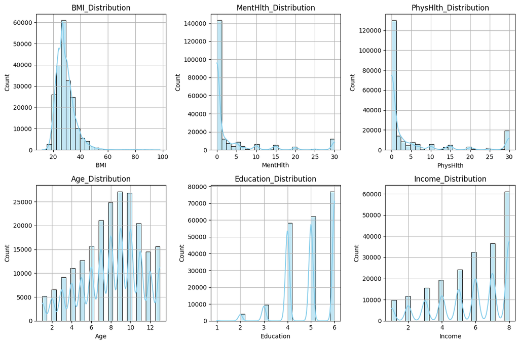

```python
num_columns = ['BMI', 'MentHlth', 'PhysHlth', 'Age', 'Education', 'Income']
num_rows = 2
num_cols = 3

plt.figure(figsize=(12, 8))

for i, column in enumerate(num_columns, start=1):
    plt.subplot(num_rows, num_cols, i)
    sns.histplot(df[column], bins=25, kde=True, color='skyblue')
    plt.title(f'{column}_Distribution')
    plt.grid(True)

plt.tight_layout()
plt.show()
```

**Inferences:**

*BMI :* The distribution is somewhat positive skew, but there's a peak around the 20 to 40. The mean is approximately 28.38 with a standard deviation of 6.60

*MentHlth :* The resting MentHlth for most individuals is concentrated around 0 to 2.5 , with a mean of approximately 3.18 and a standard deviation of 7.41

*PhysHlth :* Most individuals have PhysHlth levels between 0 to 2.5. The mean PhysHlth level is around 4.24 with a standard deviation of 8.71

*Age :* The distribution is somewhat negative skew, but the majority of subject fall between 7 to 11. The mean is approximately 8.03 with a standard deviation of 3.05

*Education :* The distribution is somewhat negative skew, but the majority of subject fall between 4 to 6. The mean is approximately 5.05 with a standard deviation of 0.98

*Income :* The distribution is somewhat negative skew, but there's a peak around the 6 to 8. The mean is approximately 6.05 with a standard deviation of 2.07

Upon reviewing the histograms of the continuous features and cross-referencing them with the provided feature descriptions, everything appears consistent and within expected ranges.

There doesn't seem to be any noticeable noise or implausible values among the continuous variables.

### Step 4.1.2 | Categorical Variables Univariate Analysis

Categorical variables are already encoded. Anyway we do for the Binomial categories.

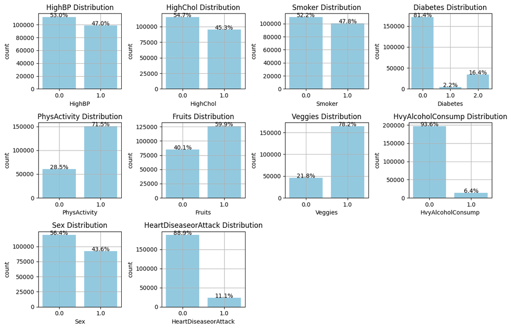

```python
plt.figure(figsize=(12, 8))

cat_columns = ['HighBP', 'HighChol', 'Smoker', 'Diabetes', 'PhysActivity', 'Fruits', 'Veggies', 'HvyAlcoholConsump', 'Sex','HeartDiseaseorAttack']

for i, column in enumerate(cat_columns, start=1):
    plt.subplot(3, 4, i)
    ax = sns.countplot(data=df, x=column, color='skyblue')
    plt.title(f'{column} Distribution')
    plt.grid(True)

    total = len(df[column])
    for p in ax.patches:
        percentage = '{:.1f}%'.format(100 * p.get_height() / total)
        x = p.get_x() + p.get_width() / 2
        y = p.get_height()
        ax.annotate(percentage, (x, y), ha='center')

plt.tight_layout()
plt.show()
```

**Inferences:**

*HighBP :* The dataset shows almost equal distribution.

*HighChol :* The dataset shows almost equal distribution.

*Smoker :* The dataset shows almost equal distribution.

*Diabetes :* The dataset is predominantly no diabetes, constituting a significant majority.

*PhysActivity :* A majority of the patients do experience exercise.

*Fruits :* The dataset distribution is quiet good.

*Veggies :* Most of the people are Veggies.

*HvyAlcoholConsump :* Most of the people non alcoholic.

*Sex :* The dataset distribution is quiet good.

*HeartDiseaseorAttack :* The dataset is not balanced. So need to make the dataset balanced to avoid bias and variance.

**Understanding the Imbalanced Data Problem:**

*Dataset:* 89% of the data points represent individuals without heart disease (class 0), while only 11% represent individuals with heart disease (class 1). *Challenge:* This uneven distribution makes it difficult for most machine learning algorithms to learn effectively. They tend to bias predictions towards the majority class (class 0), as they prioritize minimizing overall error. This results in poor performance for the minority class (class 1), which is crucial in this case for accurate heart disease prediction.

**Methods to Address Imbalanced Data:**

1. *Data Oversampling*
2. *Data Undersampling*
3. *Cost-Sensitive Learning*
4. *Ensemble Learning*
5. *Class-Weighting*

Here I'm choosing the *Data Oversampling* method and it will be done after train test split.

### Step 4.2 | Bivariate Analysis

**For our bivariate analysis on the dataset's features with respect to the target variable:**

*For continuous data:*using bar plots to showcase the average value of each feature for the different target classes, and KDE plots to understand the distribution of each feature across the target classes. This aids in discerning how each feature varies between the two target outcomes.

*For categorical data:* employing 100% stacked bar plots to depict the proportion of each category across the target classes. This offers a comprehensive view of how different categories within a feature relate to the target.

Through these visualization techniques, going to gain a deeper understanding of the relationship between individual features and the target, revealing potential predictors for heart disease.

### Step 4.2.1 | Numerical Features vs Target

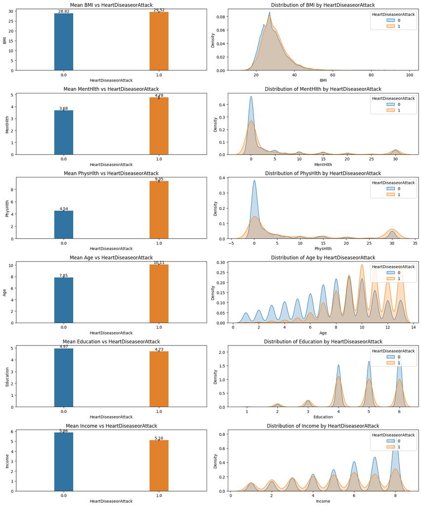

```python
tar_column = 'HeartDiseaseorAttack'

fig, axes = plt.subplots(nrows=len(num_columns), ncols=2, figsize=(15, 3*len(num_columns)))

for i, feature in enumerate(num_columns):
    # Bar plot - showing mean values
    sns.barplot(x=tar_column, y=feature, data=df, ax=axes[i][0], width=0.2)
    axes[i][0].set_title(f'Mean {feature} vs {tar_column}')

    # Add data labels to the bar plot
    for p in axes[i][0].patches:
        axes[i][0].annotate(f'{p.get_height():.2f}', (p.get_x() + p.get_width() / 2., p.get_height()),
                            ha='center', va='center', fontsize=10, color='black', xytext=(0, 5),
                            textcoords='offset points')

    # KDE plot - displaying distribution for each target category
    sns.kdeplot(data=df[df[tar_column] == 0][feature], label='0', fill=True, ax=axes[i][1] , bw_adjust=0.8)
    sns.kdeplot(data=df[df[tar_column] == 1][feature], label='1', fill=True, ax=axes[i][1] , bw_adjust=0.8)
    axes[i][1].set_title(f'Distribution of {feature} by {tar_column}')
    axes[i][1].legend(title=tar_column)

plt.tight_layout()
plt.show()
```

### Step 4.2.2 | Categorical Features vs Target

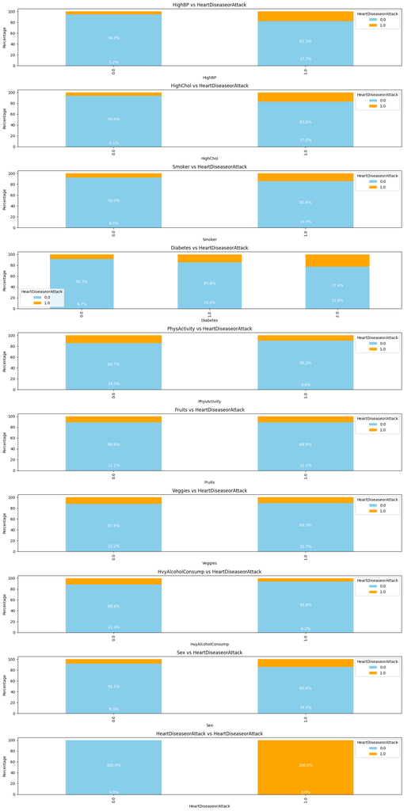

```python
fig, axes = plt.subplots(nrows=len(cat_columns), ncols=1, figsize=(15, 3*len(cat_columns)))

for i, feature in enumerate(cat_columns):
    # Compute the frequency table
    cross_tab = pd.crosstab(df[feature], df[tar_column], normalize='index') * 100

    # Plot the stacked bar plot
    cross_tab.plot(kind='bar', stacked=True, ax=axes[i], color=['skyblue', 'orange'])
    axes[i].set_title(f'{feature} vs {tar_column}')
    axes[i].set_xlabel(feature)
    axes[i].set_ylabel('Percentage')

    # Add counts and percentages on the bars
    for p in axes[i].patches:
        height = p.get_height()
        axes[i].annotate(f'{height:.1f}%', (p.get_x() + p.get_width() / 2., height / 2),
                         ha='center', va='center', fontsize=10, color='white', xytext=(0, 5),
                         textcoords='offset points')

plt.tight_layout()
plt.show()
```

### Step 5 | Data Preprocessing

### Step 5.1 | Irrelevant Features Removal

```python
df = df.drop(['Education','Income'],axis = 1)
```

```python
df.columns
```

```
Index(['HeartDiseaseorAttack', 'HighBP', 'HighChol', 'BMI', 'Smoker',
       'Diabetes', 'PhysActivity', 'Fruits', 'Veggies', 'HvyAlcoholConsump',
       'MentHlth', 'PhysHlth', 'Sex', 'Age'],
      dtype='object')
```

### Step 5.2 | Missing Value Treatment

```python
df.isnull().sum().sum()
```

```
0
```

Upon our above inspection, it is obvious that there are no missing values in our dataset. This is ideal as it means we don't have to make decisions about imputation or removal, which can introduce bias or reduce our already limited dataset size.

### Step 5.3 | Distribution analysis

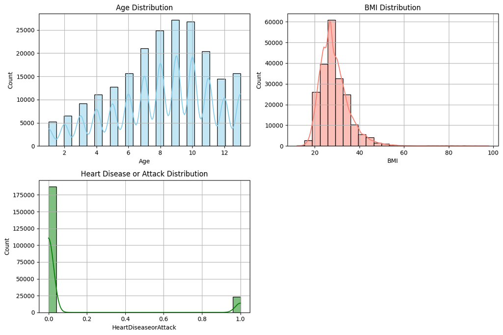

```python
plt.figure(figsize=(12, 8))

plt.subplot(2, 2, 1)
sns.histplot(df['Age'], bins=25, kde=True, color='skyblue')
plt.title('Age Distribution')
plt.grid(True)

plt.subplot(2, 2, 2)
sns.histplot(df['BMI'], bins=25, kde=True, color='salmon')
plt.title('BMI Distribution')
plt.grid(True)

plt.subplot(2, 2, 3)
sns.histplot(df['HeartDiseaseorAttack'], bins=25, kde=True, color='green')
plt.title('Heart Disease or Attack Distribution')
plt.grid(True)

plt.tight_layout()
plt.show()
```

### Step 5.4 | Outlier Treatment

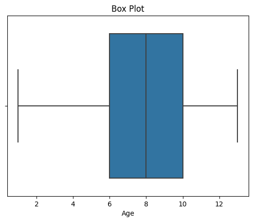

```python
sns.boxplot(x='Age', data=df)
plt.title('Box Plot')
plt.show()
```

```python
column_data = df['Age']

Q1 = column_data.quantile(0.25)
Q3 = column_data.quantile(0.75)
IQR = Q3 - Q1

print(f'Q1 (25th percentile): {Q1}')
print(f'Q3 (75th percentile): {Q3}')
print(f'IQR (Interquartile Range): {IQR}')
```

```
Q1 (25th percentile): 6.0
Q3 (75th percentile): 10.0
IQR (Interquartile Range): 4.0
```

```python
lower_bound = Q1 - 1.5 * IQR
upper_bound = Q3 + 1.5 * IQR

print(f'lower_bound: {lower_bound}')
print(f'upper_bound: {upper_bound}')
```

```
lower_bound: 0.0
upper_bound: 16.0
```

```python
df = df[(column_data >= lower_bound) & (column_data <= upper_bound)]
```

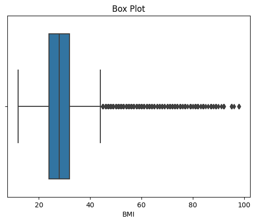

```python
sns.boxplot(x='BMI', data=df)
plt.title('Box Plot')
plt.show()
```

```python
column_data = df['BMI']

Q1 = column_data.quantile(0.25)
Q3 = column_data.quantile(0.75)
IQR = Q3 - Q1

print(f'Q1 (25th percentile): {Q1}')
print(f'Q3 (75th percentile): {Q3}')
print(f'IQR (Interquartile Range): {IQR}')
```

```
Q1 (25th percentile): 24.0
Q3 (75th percentile): 32.0
IQR (Interquartile Range): 8.0
```

```python
lower_bound = Q1 - 1.5 * IQR
upper_bound = Q3 + 1.5 * IQR

print(f'lower_bound: {lower_bound}')
print(f'upper_bound: {upper_bound}')
```

```
lower_bound: 12.0
upper_bound: 44.0
```

```python
df = df[(column_data >= lower_bound) & (column_data <= upper_bound)]
```

```python
df.describe().T
```

|  | count | mean | std | min | 25% | 50% | 75% | max |
| --- | --- | --- | --- | --- | --- | --- | --- | --- |
| HeartDiseaseorAttack | 205198.0 | 0.110415 | 0.313407 | 0.0 | 0.0 | 0.0 | 0.0 | 1.0 |
| HighBP | 205198.0 | 0.464654 | 0.498750 | 0.0 | 0.0 | 0.0 | 1.0 | 1.0 |
| HighChol | 205198.0 | 0.452324 | 0.497723 | 0.0 | 0.0 | 0.0 | 1.0 | 1.0 |
| BMI | 205198.0 | 28.241659 | 5.507658 | 12.0 | 24.0 | 27.0 | 32.0 | 44.0 |
| Smoker | 205198.0 | 0.478694 | 0.499547 | 0.0 | 0.0 | 0.0 | 1.0 | 1.0 |
| Diabetes | 205198.0 | 0.339462 | 0.736267 | 0.0 | 0.0 | 0.0 | 0.0 | 2.0 |
| PhysActivity | 205198.0 | 0.720231 | 0.448887 | 0.0 | 0.0 | 1.0 | 1.0 | 1.0 |
| Fruits | 205198.0 | 0.600483 | 0.489800 | 0.0 | 0.0 | 1.0 | 1.0 | 1.0 |
| Veggies | 205198.0 | 0.782980 | 0.412217 | 0.0 | 1.0 | 1.0 | 1.0 | 1.0 |
| HvyAlcoholConsump | 205198.0 | 0.065444 | 0.247308 | 0.0 | 0.0 | 0.0 | 0.0 | 1.0 |
| MentHlth | 205198.0 | 3.724632 | 7.887078 | 0.0 | 0.0 | 0.0 | 3.0 | 30.0 |
| PhysHlth | 205198.0 | 4.951505 | 9.217471 | 0.0 | 0.0 | 0.0 | 5.0 | 30.0 |
| Sex | 205198.0 | 0.439395 | 0.496315 | 0.0 | 0.0 | 0.0 | 1.0 | 1.0 |
| Age | 205198.0 | 8.130377 | 3.113529 | 1.0 | 6.0 | 9.0 | 10.0 | 13.0 |

**Sensitivity to Outliers:**

*SVM (Support Vector Machine):* SVMs can be sensitive to outliers. While the decision boundary is determined primarily by the support vectors, outliers can influence which data points are chosen as support vectors, potentially leading to suboptimal classification.

*Decision Trees (DT) and Random Forests (RF):* These tree-based algorithms are generally robust to outliers. They make splits based on feature values, and outliers often end up in leaf nodes, having minimal impact on the overall decision-making process.

*K-Nearest Neighbors (KNN):* KNN is sensitive to outliers because it relies on distances between data points to make predictions. Outliers can distort these distances.

*AdaBoost:* This ensemble method, which often uses decision trees as weak learners, is generally robust to outliers. However, the iterative nature of AdaBoost can sometimes lead to overemphasis on outliers, making the final model more sensitive to them.

**Approaches for Outlier Treatment:**

*Removal of Outliers:* Directly discard data points that fall outside of a defined range, typically based on a method like the Interquartile Range (IQR).

*Capping Outliers:* Instead of removing, we can limit outliers to a certain threshold, such as the 1st or 99th percentile.

*Transformations:* Applying transformations like log or Box-Cox can reduce the impact of outliers and make the data more Gaussian-like.

*Robust Scaling:* Techniques like the RobustScaler in Scikit-learn can be used, which scales features using statistics that are robust to outliers.

### Step 5.5 | Categorical Features Encoding

```python
df.groupby(['Sex'])['HeartDiseaseorAttack'].mean()
```

```
Sex
0.0    0.084557
1.0    0.143407
Name: HeartDiseaseorAttack, dtype: float64
```

```python
df.groupby(['Smoker'])['HeartDiseaseorAttack'].mean()
```

```
Smoker
0.0    0.079872
1.0    0.143677
Name: HeartDiseaseorAttack, dtype: float64
```

```python
df.groupby(['HvyAlcoholConsump'])['HeartDiseaseorAttack'].mean()
```

```
HvyAlcoholConsump
0.0    0.113793
1.0    0.062179
Name: HeartDiseaseorAttack, dtype: float64
```

```python
df.groupby(['HighBP'])['HeartDiseaseorAttack'].mean()
```

```
HighBP
0.0    0.052425
1.0    0.177228
Name: HeartDiseaseorAttack, dtype: float64
```

```python
def BMI_Cat(bmi):
    if bmi < 18.5:
        return 'Underweight'
    elif 18.5 <= bmi <= 24.9:
        return 'Normal weight'
    elif 25 <= bmi <= 29.9:
        return 'Overweight'
    elif bmi >= 30:
        return 'Obesity'
    else:
        return 'Unknown'
```

```python
df['BMI_Category'] = df['BMI'].apply(BMI_Cat)
```

```python
def Ment_Cat(ment):
    if ment < 4:
        return 'Low'
    elif 4 <= ment < 7:
        return 'Moderate'
    elif ment >= 7:
        return 'High'
    else:
        return 'Unknown'
```

```python
df['Ment_Category'] = df['MentHlth'].apply(Ment_Cat)
```

```python
def Phys_Cat(phys):
    if ment < 10:
        return 'Low'
    elif 10 <= ment < 20:
        return 'Moderate'
    elif ment >= 20:
        return 'High'
    else:
        return 'Unknown'
```

```python
df['Phys_Category'] = df['PhysHlth'].apply(Ment_Cat)
```

```python
df = df.drop(['BMI','MentHlth','PhysHlth'],axis = 1)
```

```python
df.groupby(['Phys_Category'])['HeartDiseaseorAttack'].mean()
```

```
Phys_Category
High        0.199559
Low         0.083395
Moderate    0.125233
Name: HeartDiseaseorAttack, dtype: float64
```

```python
df.groupby(['BMI_Category'])['HeartDiseaseorAttack'].mean()
```

```
BMI_Category
Normal weight    0.087575
Obesity          0.123138
Overweight       0.113567
Underweight      0.111036
Name: HeartDiseaseorAttack, dtype: float64
```

```python
df.groupby(['Ment_Category'])['HeartDiseaseorAttack'].mean()
```

```
Ment_Category
High        0.135511
Low         0.106671
Moderate    0.091605
Name: HeartDiseaseorAttack, dtype: float64
```

```python
oe_col_val =  [['Underweight', 'Normal weight', 'Overweight', 'Obesity', 'Unknown'], ['Low', 'Moderate', 'High', 'Unknown'], ['Low', 'Moderate', 'High', 'Unknown']]
```

```python
oe = OrdinalEncoder(categories = oe_col_val )
```

```python
oe_col = ['BMI_Category', 'Ment_Category', 'Phys_Category']
```

```python
df[oe_col] = oe.fit_transform(df[oe_col])
```

### Step 5.6 | Correlation with target variable

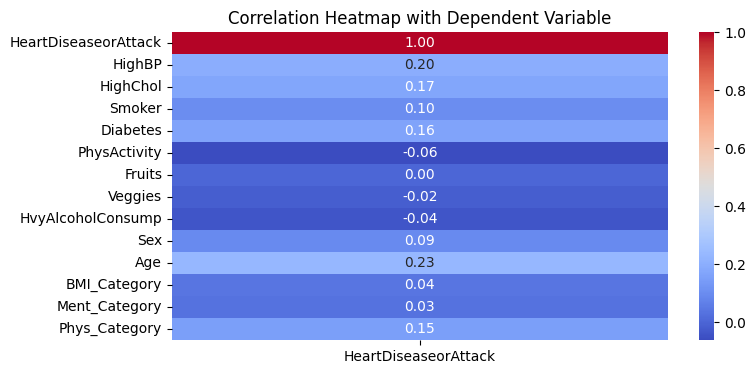

```python
correlation_matrix = df.corr()
plt.figure(figsize=(8, 4))
sns.heatmap(correlation_matrix[['HeartDiseaseorAttack']], annot=True, cmap='coolwarm', fmt=".2f")
plt.title('Correlation Heatmap with Dependent Variable')
plt.show()
```

```python
df = df.drop(['PhysActivity','Fruits','Veggies','HvyAlcoholConsump','BMI_Category','Ment_Category'], axis=1)
```

```python
X = df.drop('HeartDiseaseorAttack', axis=1)
y = df['HeartDiseaseorAttack']
```

### Step 5.7 | Feature Scaling

```python
scaler = MinMaxScaler()
```

```python
X_scaled = scaler.fit_transform(X)
```

While feature scaling is vital for some models, not all algorithms require scaled data.

For instance, Decision Tree-based models are scale-invariant. Given our intent to use a mix of models (some requiring scaling, others not), we've chosen to handle scaling.

This approach lets us ensuring flexibility and efficiency in our modeling process.

### Step 5.8 | Heatmap

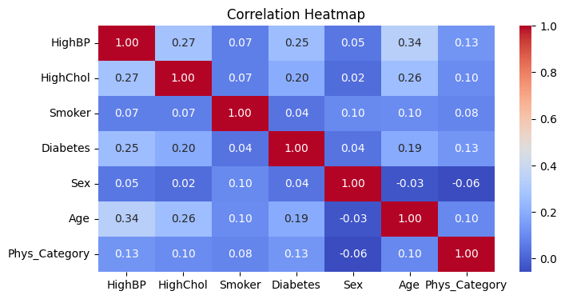

```python
plt.figure(figsize=(8, 4))
sns.heatmap(pd.DataFrame(X_scaled, columns=X.columns).corr(), annot=True, cmap='coolwarm', fmt=".2f")
plt.title('Correlation Heatmap')
plt.show()
```

### Step 5.9 | Train - Test Split

```python
X_train, X_test, y_train, y_test = train_test_split(X_scaled, y, test_size=0.2, random_state=42)
```

### Step 5.9.1 | Data Oversampling

As discussed earlier I'm using *Data Oversampling* method to Address Imbalanced Data

```python
# Create an ADASYN object
adasyn = ADASYN(random_state=42)
```

```python
# Oversample the data
X_train_res, y_train_res = adasyn.fit_resample(X_train, y_train)
```

Now, we can cross check the class count for oversampling improvement

```python
original_counts = Counter(y_train)
print("Original class counts:", original_counts)

oversampled_counts = Counter(y_train_res)
print("Oversampled class counts:", oversampled_counts)
```

```
Original class counts: Counter({0.0: 145964, 1.0: 18194})
Oversampled class counts: Counter({0.0: 145964, 1.0: 143019})
```

### Step 6 | Decision Tree Model Building

### Step 6.1 | DT Base Model Definition

```python
DT_model = DecisionTreeClassifier(random_state=42)
DT_model.fit(X_train_res, y_train_res)
y_pred_base_DT = DT_model.predict(X_test)
```

```python
print("Base Model Performance:")
print("Accuracy:",accuracy_score(y_test, y_pred_base_DT))

print("\nClassification Report:")
print(classification_report(y_test, y_pred_base_DT))

print("\nConfusion Matrix:")
print(confusion_matrix(y_test, y_pred_base_DT))
```

```
Base Model Performance:
Accuracy: 0.6784844054580896

Classification Report:
              precision    recall  f1-score   support

         0.0       0.96      0.67      0.79     36577
         1.0       0.22      0.77      0.34      4463

    accuracy                           0.68     41040
   macro avg       0.59      0.72      0.57     41040
weighted avg       0.88      0.68      0.74     41040


Confusion Matrix:
[[24391 12186]
 [ 1009  3454]]
```

### Step 6.2 | DT Hyperparameter Tuning

```python
param_grid_DT = {
    'criterion': ['gini', 'entropy'],
    'max_depth': [None, 5, 10, 15],
    'min_samples_split': [2, 5, 10],
    'min_samples_leaf': [1, 2, 4]
}
```

```python
grid_search_DT = GridSearchCV(DecisionTreeClassifier(random_state=42), param_grid_DT, cv=5)
grid_search_DT.fit(X_train_res, y_train_res)
```

```
GridSearchCV(cv=5, estimator=DecisionTreeClassifier(random_state=42),
             param_grid={'criterion': ['gini', 'entropy'],
                         'max_depth': [None, 5, 10, 15],
                         'min_samples_leaf': [1, 2, 4],
                         'min_samples_split': [2, 5, 10]})
```

```python
best_params_DT = grid_search_DT.best_params_
print("\nBest Hyperparameters:", best_params_DT)
```

```
Best Hyperparameters: {'criterion': 'entropy', 'max_depth': None, 'min_samples_leaf': 1, 'min_samples_split': 2}
```

### Step 6.3 | DT Model Evaluation

```python
best_model_DT = grid_search_DT.best_estimator_
y_pred_best_DT = best_model_DT.predict(X_test)
```

```python
print("\nBest Model Performance:")
accuracy_DT = accuracy_score(y_test, y_pred_best_DT)
print(f'Accuracy: {accuracy_DT}')

print("\nClassification Report:")
print(classification_report(y_test, y_pred_best_DT, zero_division=1))

print("\nConfusion Matrix:")
print(confusion_matrix(y_test, y_pred_best_DT))

unique_classes = set(np.unique(y_test)).union(set(np.unique(y_pred_best_DT)))
print("Classes in Test and Predictions:", unique_classes)
```

```
Best Model Performance:
Accuracy: 0.6784844054580896

Classification Report:
              precision    recall  f1-score   support

         0.0       0.96      0.67      0.79     36577
         1.0       0.22      0.77      0.34      4463

    accuracy                           0.68     41040
   macro avg       0.59      0.72      0.57     41040
weighted avg       0.88      0.68      0.74     41040


Confusion Matrix:
[[24390 12187]
 [ 1008  3455]]
Classes in Test and Predictions: {0.0, 1.0}
```

### Step 7 | Random Forest Model Building

### Step 7.1 | RF Base Model Definition

```python
RF_model = RandomForestClassifier(random_state=42)
RF_model.fit(X_train_res, y_train_res)
y_pred_base_RF = RF_model.predict(X_test)
```

```python
print("Base Model Performance:")
print("Accuracy:", accuracy_score(y_test, y_pred_base_RF))

print("\nClassification Report:")
print(classification_report(y_test, y_pred_base_RF))

print("\nConfusion Matrix:")
print(confusion_matrix(y_test, y_pred_base_RF))
```

```
Base Model Performance:
Accuracy: 0.6785575048732944

Classification Report:
              precision    recall  f1-score   support

         0.0       0.96      0.67      0.79     36577
         1.0       0.22      0.77      0.34      4463

    accuracy                           0.68     41040
   macro avg       0.59      0.72      0.57     41040
weighted avg       0.88      0.68      0.74     41040


Confusion Matrix:
[[24391 12186]
 [ 1006  3457]]
```

### Step 7.2 | RF Hyperparameter Tuning

```python
param_grid_RF = {
    'n_estimators': [50, 100, 150],
    'max_depth': [None, 5, 10, 15],
    'min_samples_split': [2, 5, 10],
    'min_samples_leaf': [1, 2, 4]
}
```

```python
grid_search_RF = GridSearchCV(RandomForestClassifier(random_state=42), param_grid_RF, cv=5)
grid_search_RF.fit(X_train_res, y_train_res)
```

```
GridSearchCV(cv=5, estimator=RandomForestClassifier(random_state=42),
             param_grid={'max_depth': [None, 5, 10, 15],
                         'min_samples_leaf': [1, 2, 4],
                         'min_samples_split': [2, 5, 10],
                         'n_estimators': [50, 100, 150]})
```

```python
best_params_RF = grid_search_RF.best_params_
print("\nBest Hyperparameters:", best_params_RF)
```

```
Best Hyperparameters: {'max_depth': 15, 'min_samples_leaf': 2, 'min_samples_split': 2, 'n_estimators': 50}
```

### Step 7.3 | RF Model Evaluation

```python
best_model_RF = grid_search_RF.best_estimator_
y_pred_best_RF = best_model_RF.predict(X_test)
```

```python
print("\nBest Model Performance:")
accuracy_RF = accuracy_score(y_test, y_pred_best_RF)
print(f'Accuracy: {accuracy_RF}')

print("\nClassification Report:")
print(classification_report(y_test, y_pred_best_RF, zero_division=1))

print("\nConfusion Matrix:")
print(confusion_matrix(y_test, y_pred_best_RF))

unique_classes = set(np.unique(y_test)).union(set(np.unique(y_pred_best_RF)))
print("Classes in Test and Predictions:", unique_classes)
```

```
Best Model Performance:
Accuracy: 0.6744152046783626

Classification Report:
              precision    recall  f1-score   support

         0.0       0.96      0.66      0.78     36577
         1.0       0.22      0.78      0.34      4463

    accuracy                           0.67     41040
   macro avg       0.59      0.72      0.56     41040
weighted avg       0.88      0.67      0.74     41040


Confusion Matrix:
[[24181 12396]
 [  966  3497]]
Classes in Test and Predictions: {0.0, 1.0}
```

### Step 8 | KNN Model Building

### Step 8.1 | KNN Base Model Definition

```python
knn = KNeighborsClassifier()
```

### Step 8.2 | KNN Hyperparameter Tuning

```python
param_grid_knn = {
    'n_neighbors': [3, 5, 7, 9, 11],
    'weights': ['uniform', 'distance'],
    'metric': ['euclidean', 'manhattan']
}
```

```python
grid_search_knn = GridSearchCV(knn, param_grid_knn, cv=5, scoring='accuracy')
grid_search_knn.fit(X_train_res, y_train_res)
```

```
GridSearchCV(cv=5, estimator=KNeighborsClassifier(),
             param_grid={'metric': ['euclidean', 'manhattan'],
                         'n_neighbors': [3, 5, 7, 9, 11],
                         'weights': ['uniform', 'distance']},
             scoring='accuracy')
```

```python
best_params_knn = grid_search_knn.best_params_
print("Best Parameters:", best_params_knn)
```

```
Best Parameters: {'metric': 'euclidean', 'n_neighbors': 3, 'weights': 'distance'}
```

### Step 8.3 | KNN Model Evaluation

```python
best_knn_model = KNeighborsClassifier(**best_params_knn)
best_knn_model.fit(X_train_res, y_train_res)

y_pred_knn = best_knn_model.predict(X_test)
```

```python
accuracy_knn = accuracy_score(y_test, y_pred_knn)
print(f'Accuracy: {accuracy_knn}')

print(classification_report(y_test, y_pred_knn))

print(confusion_matrix(y_test, y_pred_knn))
```

```
Accuracy: 0.8721491228070175
              precision    recall  f1-score   support

         0.0       0.90      0.96      0.93     36577
         1.0       0.32      0.15      0.21      4463

    accuracy                           0.87     41040
   macro avg       0.61      0.56      0.57     41040
weighted avg       0.84      0.87      0.85     41040

[[35113  1464]
 [ 3783   680]]
```

Here, the below SVM model development which takes more time and memory consuming process comes around O(n^3) of time. Due to lack of CPU capacity I'm skipping this SVM model building but I have mentioned the code below for reference.

### Step 9 | SVM Model Building

### Step 9.1 | SVM Base Model Definition

```python
svm = SVC()
```

### Step 9.2 | SVM Hyperparameter Tuning

```python
'''

param_grid_svm = {
    'C': [0.1, 1, 10, 100],
    'gamma': ['scale', 'auto'],
    'kernel': ['linear', 'rbf', 'poly']
}

'''
```

```
"\n\nparam_grid_svm = {\n    'C': [0.1, 1, 10, 100],\n    'gamma': ['scale', 'auto'],\n    'kernel': ['linear', 'rbf', 'poly']\n}\n\n"
```

```python
'''

grid_search_svm = GridSearchCV(svm, param_grid_svm, cv=5, scoring='accuracy')
grid_search_svm.fit(X_train_res, y_train_res)

'''
```

```
"\n\ngrid_search_svm = GridSearchCV(svm, param_grid_svm, cv=5, scoring='accuracy')\ngrid_search_svm.fit(X_train_res, y_train_res)\n\n"
```

```python
'''

best_params_svm = grid_search_svm.best_params_
print("Best Parameters:", best_params_svm)

'''
```

```
'\n\nbest_params_svm = grid_search_svm.best_params_\nprint("Best Parameters:", best_params_svm)\n\n'
```

### Step 9.3 | SVM Model Evaluation

```python
'''

best_svm_model = SVC(**best_params_svm)
best_svm_model.fit(X_train_res, y_train_res)

y_pred_svm = best_svm_model.predict(X_test)

'''
```

```
'\n\nbest_svm_model = SVC(**best_params_svm)\nbest_svm_model.fit(X_train_res, y_train_res)\n\ny_pred_svm = best_svm_model.predict(X_test)\n\n'
```

```python
'''

accuracy_svm = accuracy_score(y_test, y_pred)
print(f'Accuracy: {accuracy_svm}')

print(classification_report(y_test, y_pred))

print(confusion_matrix(y_test, y_pred))

'''
```

```
"\n\naccuracy_svm = accuracy_score(y_test, y_pred)\nprint(f'Accuracy: {accuracy_svm}')\n\nprint(classification_report(y_test, y_pred))\n\nprint(confusion_matrix(y_test, y_pred))\n\n"
```

### Step 10 | LogisticRegression Model Building

### Step 10.1 | LogisticRegression Base Model Definition

```python
lr = LogisticRegression()
```

### Step 10.2 | LogisticRegression Hyperparameter Tuning

```python
param_grid_lr = {
    'penalty': ['l2'],
    'C': [0.001, 0.01, 0.1, 1, 10, 100],
    'solver': ['lbfgs']
}
```

```python
grid_search_lr = GridSearchCV(lr, param_grid_lr, cv=5, scoring='accuracy')
grid_search_lr.fit(X_train_res, y_train_res)
```

```
GridSearchCV(cv=5, estimator=LogisticRegression(),
             param_grid={'C': [0.001, 0.01, 0.1, 1, 10, 100], 'penalty': ['l2'],
                         'solver': ['lbfgs']},
             scoring='accuracy')
```

```python
best_params_lr = grid_search_lr.best_params_
print("Best Parameters:", best_params_lr)
```

```
Best Parameters: {'C': 0.01, 'penalty': 'l2', 'solver': 'lbfgs'}
```

### Step 10.3 | LogisticRegression Model Evaluation

```python
best_lr_model = LogisticRegression(**best_params_lr)
best_lr_model.fit(X_train_res, y_train_res)

y_pred_lr = best_lr_model.predict(X_test)
```

```python
accuracy_lr = accuracy_score(y_test, y_pred_lr)
print(f'Accuracy: {accuracy_lr}')

print(classification_report(y_test, y_pred_lr))
print(confusion_matrix(y_test, y_pred_lr))
```

```
Accuracy: 0.6894493177387915
              precision    recall  f1-score   support

         0.0       0.96      0.68      0.80     36577
         1.0       0.23      0.78      0.35      4463

    accuracy                           0.69     41040
   macro avg       0.60      0.73      0.57     41040
weighted avg       0.88      0.69      0.75     41040

[[24810 11767]
 [  978  3485]]
```

### Step 11 | Naive Bayes Model Building

### Step 11.1 | Naive Bayes Model Definition

```python
nb = GaussianNB()
```

### Step 11.2 | Naive Bayes Hyperparameter Tuning

```python
param_grid_nb = {
    'var_smoothing': [1e-9, 1e-7, 1e-5, 1e-3, 1e-1]  # Smoothing parameter
}
```

```python
grid_search_nb = GridSearchCV(nb, param_grid_nb, cv=5, scoring='accuracy')
grid_search_nb.fit(X_train_res, y_train_res)
```

```
GridSearchCV(cv=5, estimator=GaussianNB(),
             param_grid={'var_smoothing': [1e-09, 1e-07, 1e-05, 0.001, 0.1]},
             scoring='accuracy')
```

```python
best_params_nb = grid_search_nb.best_params_
print("Best Parameters:", best_params_nb)
```

```
Best Parameters: {'var_smoothing': 1e-09}
```

### Step 11.3 | Naive Bayes Model Evaluation

```python
best_nb_model = GaussianNB(**best_params_nb)
best_nb_model.fit(X_train_res, y_train_res)

y_pred_nb = best_nb_model.predict(X_test)
```

```python
accuracy_nb = accuracy_score(y_test, y_pred_nb)
print(f'Accuracy: {accuracy_nb}')

print(classification_report(y_test, y_pred_nb))
print(confusion_matrix(y_test, y_pred_nb))
```

```
Accuracy: 0.6835769980506823
              precision    recall  f1-score   support

         0.0       0.96      0.67      0.79     36577
         1.0       0.22      0.76      0.34      4463

    accuracy                           0.68     41040
   macro avg       0.59      0.72      0.57     41040
weighted avg       0.88      0.68      0.74     41040

[[24656 11921]
 [ 1065  3398]]
```

### Step 12 | XGBoost classifier Model Building

### Step 12.1 | XGBoost classifier Model Definition

```python
xgb_model = XGBClassifier()
```

### Step 12.2 | XGBoost classifier Hyperparameter Tuning

```python
param_grid_xgb = {
    'n_estimators': [50, 100, 200],
    'learning_rate': [0.05, 0.1, 0.2],
    'max_depth': [3, 5, 8],
    'subsample': [0.5, 0.7, 1],
    'colsample_bytree': [0.5, 0.7, 1],
}
```

```python
grid_search_xgb = GridSearchCV(xgb_model, param_grid_xgb, cv=5, scoring='accuracy')
grid_search_xgb.fit(X_train_res, y_train_res)
```

```
GridSearchCV(cv=5,
             estimator=XGBClassifier(base_score=None, booster=None,
                                     callbacks=None, colsample_bylevel=None,
                                     colsample_bynode=None,
                                     colsample_bytree=None, device=None,
                                     early_stopping_rounds=None,
                                     enable_categorical=False, eval_metric=None,
                                     feature_types=None, gamma=None,
                                     grow_policy=None, importance_type=None,
                                     interaction_constraints=None,
                                     learning_rate=None,...
                                     max_delta_step=None, max_depth=None,
                                     max_leaves=None, min_child_weight=None,
                                     missing=nan, monotone_constraints=None,
                                     multi_strategy=None, n_estimators=None,
                                     n_jobs=None, num_parallel_tree=None,
                                     random_state=None, ...),
             param_grid={'colsample_bytree': [0.5, 0.7, 1],
                         'learning_rate': [0.05, 0.1, 0.2],
                         'max_depth': [3, 5, 8], 'n_estimators': [50, 100, 200],
                         'subsample': [0.5, 0.7, 1]},
             scoring='accuracy')
```

```python
best_params_xgb = grid_search_xgb.best_params_
print("Best Parameters:", best_params_xgb)
```

```
Best Parameters: {'colsample_bytree': 0.5, 'learning_rate': 0.2, 'max_depth': 8, 'n_estimators': 50, 'subsample': 0.7}
```

### Step 12.3 | XGBoost classifier Model Evaluation

```python
best_xgb_model = XGBClassifier(**best_params_xgb)
best_xgb_model.fit(X_train_res, y_train_res)

y_pred_xgb = best_xgb_model.predict(X_test)
```

```python
accuracy_xgb = accuracy_score(y_test, y_pred_xgb)
print(f'Accuracy: {accuracy_xgb}')

print(classification_report(y_test, y_pred_xgb))
print(confusion_matrix(y_test, y_pred_xgb))
```

```
Accuracy: 0.6784844054580896
              precision    recall  f1-score   support

         0.0       0.96      0.66      0.79     36577
         1.0       0.22      0.79      0.35      4463

    accuracy                           0.68     41040
   macro avg       0.59      0.73      0.57     41040
weighted avg       0.88      0.68      0.74     41040

[[24313 12264]
 [  931  3532]]
```

### Step 13 | Gradient Boosting Machines Model Building

### Step 13.1 | Gradient Boosting Machines Model Definition

```python
gbm_model = GradientBoostingClassifier()
```

### Step 13.2 | Gradient Boosting Machines Hyperparameter Tuning

```python
param_grid_gbm = {
    'n_estimators': [50, 100, 200],
    'learning_rate': [0.05, 0.1, 0.2],
    'max_depth': [3, 5, 8],
    'subsample': [0.5, 0.7, 1],
}
```

```python
grid_search_gbm = GridSearchCV(gbm_model, param_grid_gbm, cv=5, scoring='accuracy')
grid_search_gbm.fit(X_train_res, y_train_res)
```

```
GridSearchCV(cv=5, estimator=GradientBoostingClassifier(),
             param_grid={'learning_rate': [0.05, 0.1, 0.2],
                         'max_depth': [3, 5, 8], 'n_estimators': [50, 100, 200],
                         'subsample': [0.5, 0.7, 1]},
             scoring='accuracy')
```

```python
best_params_gbm = grid_search_gbm.best_params_
print("Best Parameters:", best_params_gbm)
```

```
Best Parameters: {'learning_rate': 0.2, 'max_depth': 8, 'n_estimators': 50, 'subsample': 1}
```

### Step 13.3 | Gradient Boosting Machines Model Evaluation

```python
best_gbm_model = GradientBoostingClassifier(**best_params_gbm)
best_gbm_model.fit(X_train_res, y_train_res)

y_pred_gbm = best_gbm_model.predict(X_test)
```

```python
accuracy_gbm = accuracy_score(y_test, y_pred_gbm)
print(f'Accuracy: {accuracy_gbm}')

print(classification_report(y_test, y_pred_gbm))
print(confusion_matrix(y_test, y_pred_gbm))
```

```
Accuracy: 0.6782651072124757
              precision    recall  f1-score   support

         0.0       0.96      0.67      0.79     36577
         1.0       0.22      0.78      0.35      4463

    accuracy                           0.68     41040
   macro avg       0.59      0.72      0.57     41040
weighted avg       0.88      0.68      0.74     41040

[[24349 12228]
 [  976  3487]]
```

### Step 14 | Artificial Neural Networks (ANN) Model Building

### Step 14.1 | Artificial Neural Networks (ANN) Model Definition

```python
def create_model(n_hidden_layers, units_per_layer, activation):
  model = keras.Sequential()
  model.add(layers.Dense(units_per_layer, activation=activation, input_shape=(X_train_res.shape[1],)))
  for _ in range(n_hidden_layers - 1):
    model.add(layers.Dense(units_per_layer, activation=activation))
  model.add(layers.Dense(1, activation='sigmoid'))
  model.compile(loss='binary_crossentropy', optimizer='adam', metrics=['accuracy'])
  return model
```

### Step 14.2 | Artificial Neural Networks (ANN) Hyperparameter Tuning

```python
param_grid_ann = {
    'n_hidden_layers': [1, 2],
    'units_per_layer': [32, 64, 128],
    'activation': ['relu', 'tanh']
}
```

```python
def grid_search_wrapper(param_grid, X_train, y_train):
    best_score = 0
    best_params = None
    best_model = None

    for params in ParameterGrid(param_grid):
        model = create_model(**params)
        model.fit(X_train, y_train)

        y_pred = model.predict(X_test)
        y_pred_classes = (y_pred > 0.5).astype("int32")
        accuracy = accuracy_score(y_test, y_pred_classes)

        if accuracy > best_score:
            best_score = accuracy
            best_params = params
            best_model = model

    return best_model, best_params
```

### Step 14.3 | Artificial Neural Networks (ANN) Model Evaluation

```python
best_model, best_params_ann = grid_search_wrapper(param_grid_ann, X_train_res, y_train_res)
```

```python
y_pred_ann = best_model.predict(X_test)
y_pred_classes = (y_pred_ann > 0.5).astype("int32")
```

```python
accuracy_ann = accuracy_score(y_test, y_pred_classes)

print(f'Accuracy: {accuracy_ann}')
print(classification_report(y_test, y_pred_classes))
print(confusion_matrix(y_test, y_pred_classes))
```

```
Accuracy: 0.7058479532163743
              precision    recall  f1-score   support

         0.0       0.96      0.70      0.81     36577
         1.0       0.23      0.75      0.36      4463

    accuracy                           0.71     41040
   macro avg       0.60      0.73      0.58     41040
weighted avg       0.88      0.71      0.76     41040

[[25614 10963]
 [ 1109  3354]]
```

### Step 15 | Conclusion

In the critical context of diagnosing heart disease, our primary objective is to ensure a high recall for the positive class. It's imperative to accurately identify every potential heart disease case, as even one missed diagnosis could have dire implications.

However, while striving for this high recall, it's essential to maintain a balanced performance to avoid unnecessary medical interventions for healthy individuals.

```
Model Accuracy (Descending):
KNN: 0.87
Artificial Neural Networks: 0.71
Logistic Regression: 0.69
Naive Bayes: 0.68
Decision Trees: 0.68
XGBoost: 0.68
Gradient Boosting Machines: 0.68
Random Forest: 0.67
```

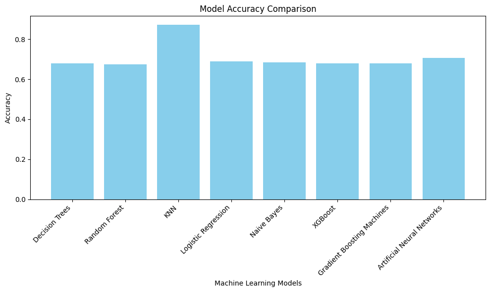

```python
models = ['Decision Trees', 'Random Forest', 'KNN', 'Logistic Regression', 'Naive Bayes', 'XGBoost', 'Gradient Boosting Machines', 'Artificial Neural Networks']
accuracies = [accuracy_DT, accuracy_RF,accuracy_knn, accuracy_lr, accuracy_nb, accuracy_xgb, accuracy_gbm, accuracy_ann]

sorted_data = sorted(zip(models, accuracies), key=lambda x: x[1], reverse=True)

print("Model Accuracy (Descending):")
for model, accuracy in sorted_data:
    print(f"{model}: {accuracy:.2f}")

plt.figure(figsize=(10, 6))
plt.bar(models, accuracies, color='skyblue')
plt.xlabel('Machine Learning Models')
plt.ylabel('Accuracy')
plt.title('Model Accuracy Comparison')
plt.xticks(rotation=45, ha='right')

plt.tight_layout()
plt.show()
```

### Step 16 | Testing the model with sample data

### Step 16.1 | Test 1

```python
input_data = [
    1.0,  # HighBP (0,1)
    1.0,  # HighChol (0,1)
    1.0,   # Smoker (0,1)
    1.0,  # Diabetes (0,1)
    1.0,  # Sex (0,1)
    20.0,   # Age (0,1)
    0.0   # Phys_Category (values 0,1,2 as low, moderate,high)
]
```

```python
prediction = best_knn_model.predict(np.array([input_data]))[0]

if prediction == 0:
  print("The model predicts the person does not have heart disease.")
elif prediction == 1:
  print("The model predicts the person has heart disease.")
else:
  print("Unexpected prediction outcome. Please review the model output.")
```

```
The model predicts the person has heart disease.
```

### Step 16.2 | Test 2

```python
input_data_2 = [
    0.0,  # HighBP (0,1)
    0.0,  # HighChol (0,1)
    0.0,   # Smoker (0,1)
    0.0,  # Diabetes (0,1)
    1.0,  # Sex (0,1)
    20.0,   # Age (0,1)
    2.0   # Phys_Category (values 0,1,2 as low, moderate,high)
]
```

```python
prediction = best_knn_model.predict(np.array([input_data_2]))[0]

if prediction == 0:
  print("The model predicts the person does not have heart disease.")
elif prediction == 1:
  print("The model predicts the person has heart disease.")
else:
  print("Unexpected prediction outcome. Please review the model output.")
```

```
The model predicts the person does not have heart disease.
```

Finally our model predicts the target variable with **87% accuracy**.